# REDStat Code Snippets

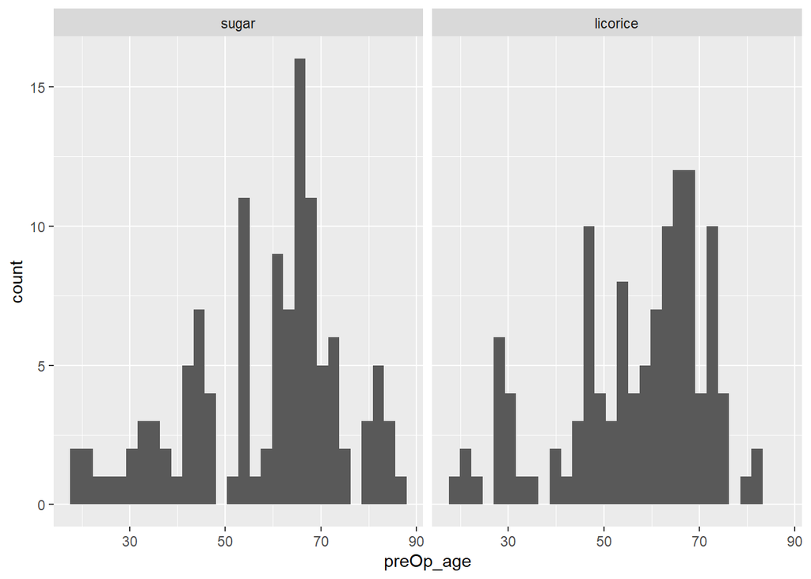

```r
licorice_gargle_clean %>%
  ggplot(aes(x = preOp_age)) +
  geom_histogram() +
  facet_wrap(~treat)
```

```r
licorice_gargle_clean %>%
  group_by(treat) %>%
  summarise(median_age = median(preOp_age, na.rm = TRUE),
            IQR_age = IQR(preOp_age, na.rm = TRUE))
```

```
## # A tibble: 2 × 3
##   treat    median_age IQR_age
##   <fct>         <dbl>   <dbl>
## 1 sugar          63        23
## 2 licorice       60.5      20
```

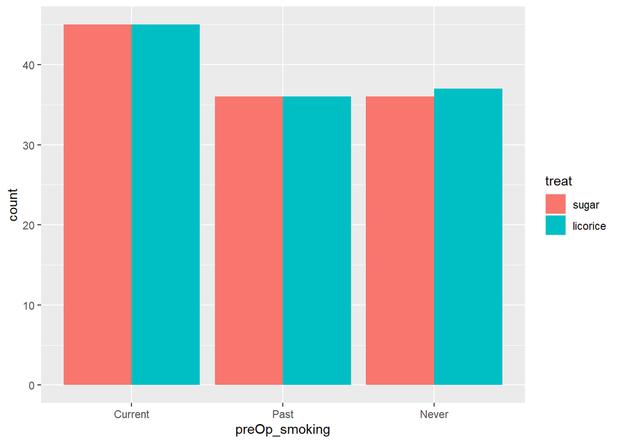

```r
## Exercise 2 ----
# Produce a bar chart that shows the distribution of smoking status in each group.
# HINT: Use a grouped bar chart.

## Your solution below:

barchart1 <- licorice_gargle_clean %>%
  ggplot() +
  geom_bar(aes(x= preOp_smoking, fill = treat), position = "dodge")

barchart1
```

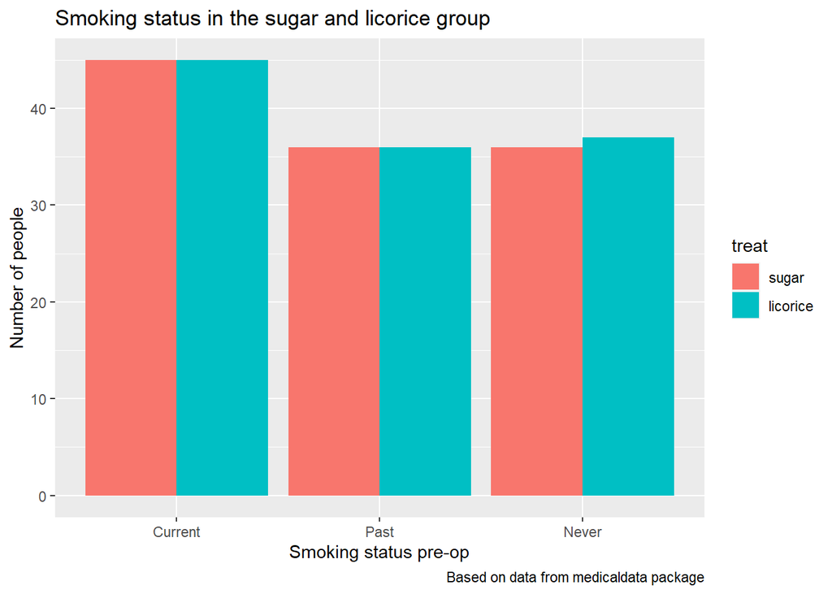

```r
barchart1 +
  labs(title = "Smoking status in the sugar and licorice group",
       x="Smoking status pre-op",
       y="Number of people",
       caption = "Based on data from medicaldata package"
       )
```

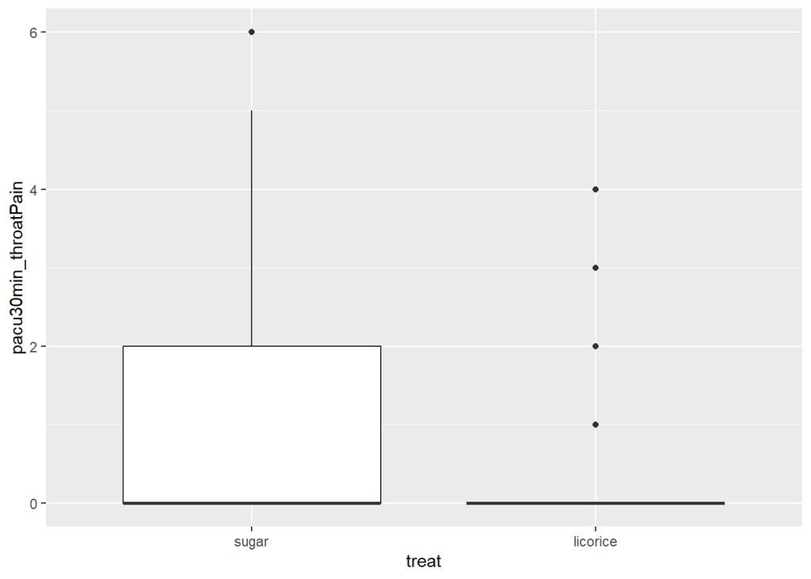

```r
## Exercise 3  ----
# Does it look like the licorice gargle reduced throat pain 30 minutes after the surgery?
# And what about cough?
# Use a graph to answer each question. If helpful, you can also create a table.

## Your solution below:
licorice_gargle_clean %>%
  ggplot(aes(x=treat, y= pacu30min_throatPain)) +
  geom_boxplot()
```

```r
licorice_gargle_clean %>%
  group_by(treat) %>%
  summarise(mean_pain = mean(pacu30min_throatPain, na.rm = TRUE),
            sd_pain = sd(pacu30min_throatPain, na.rm = TRUE),
            median_pain = median(pacu30min_throatPain, na.rm = TRUE),
            iqr_pain = IQR(pacu30min_throatPain, na.rm = TRUE))
```

```
## # A tibble: 2 × 5
##   treat    mean_pain sd_pain median_pain iqr_pain
##   <fct>        <dbl>   <dbl>       <dbl>    <dbl>
## 1 sugar        1.03    1.55            0        2
## 2 licorice     0.274   0.678           0        0
```

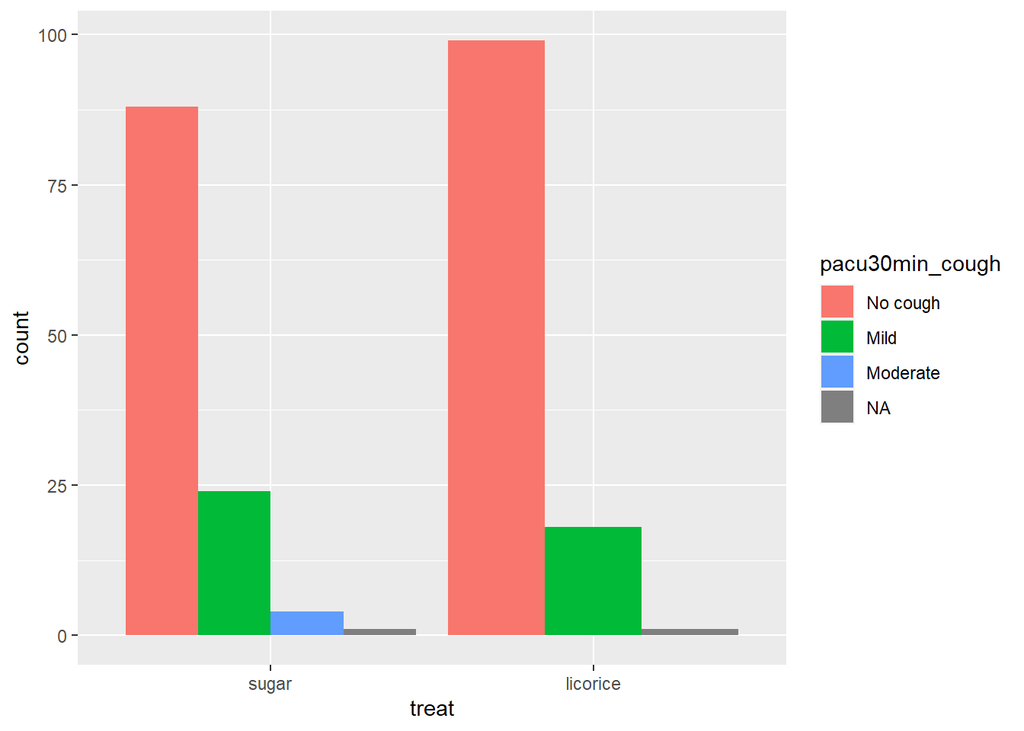

```r
licorice_gargle_clean %>%
  ggplot(aes(x = treat, fill = pacu30min_cough)) +
  geom_bar(position = "dodge")
```

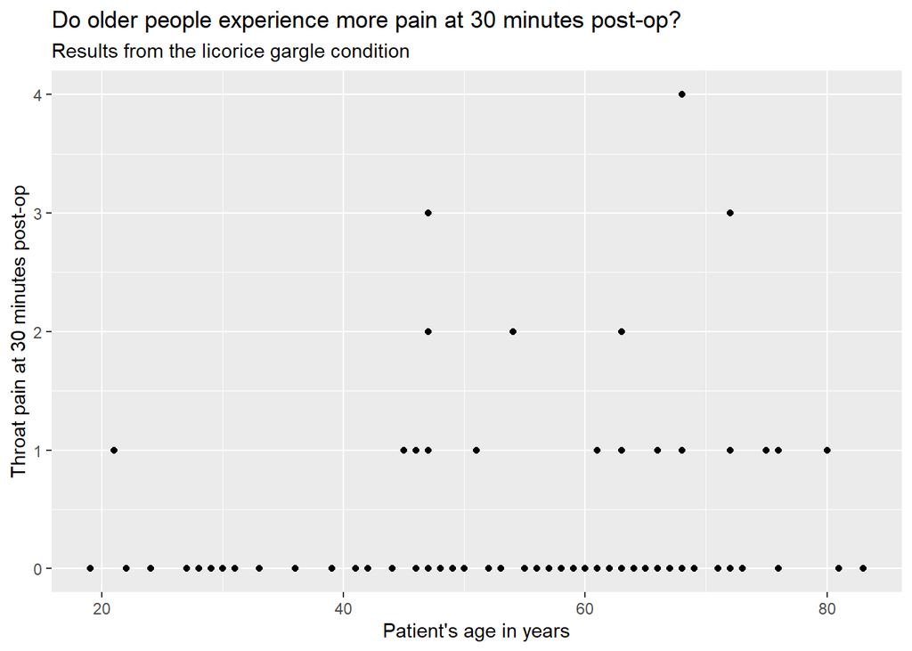

```r
## Exercise 4 ----
# Is there any evidence that in the intervention (licorice gargle) group, older people
# experienced more post-operative throat pain?
# Create a scatterplot to illustrate the relationship between age and throat pain at 30 minutes
# after the surgery, and comment on your findings.
# Remember to filter the data, so you only look at the licorice condition.

## Your solution below:
licorice_gargle_clean %>%
  filter(treat == "licorice") %>%
  ggplot() +
  geom_point(aes(x = preOp_age, y = pacu30min_throatPain)) +
  labs(title = "Do older people experience more pain at 30 minutes post-op?",
       subtitle = "Results from the licorice gargle condition",
       x = "Patient's age in years",
       y = "Throat pain at 30 minutes post-op")
```

```r
## This is the end of the lab!
## Now you're ready to complete the Week 1: 3 stars and a wish on the Discussion Board.
```

## WEEK 2

### WK2 - Codealong

ggplot of the historgram — remvoe background & and and remove grid * str() gives you an idea for all dataset * we used the pull functions - to use the shapiro test - as it doesn’t work well with tibble - it uses the height here as vector – this is why the use of pull(height)

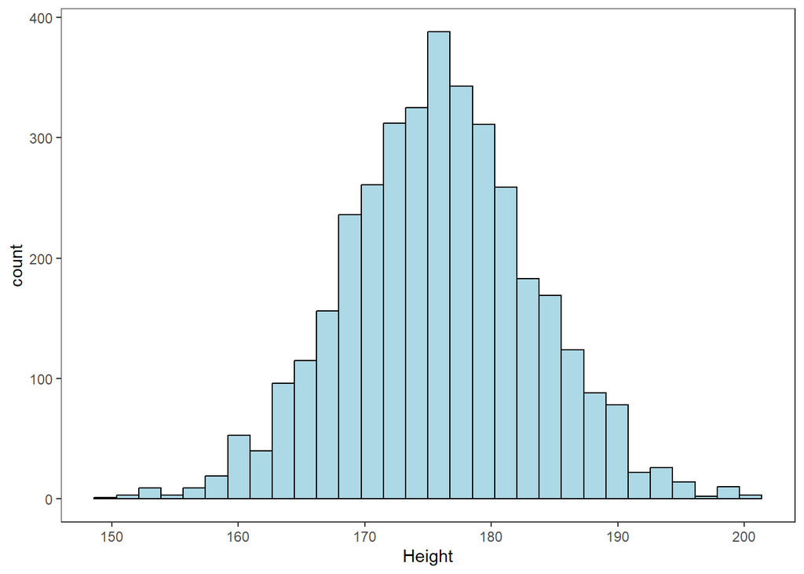

```r
###############################################################################
# EXAMPLE: Using a subset of NHANES with only male individuals aged 18 and over,
#            check the normality assumption for the Height variables.
###############################################################################

# Create a subset of the NHANES dataset with only male individuals aged 18 and over,
# who have Height information
subsetNHANES <-NHANES %>%
  filter(Gender == "male", Age >= 18) %>% ## keep only male individuals aged 18 and over
  drop_na(Height)                         ## remove rows where Height is missing (NA)

# Checking the assumption of normal distribution of Height variable

# Plot a histogram for Height
subsetNHANES %>%                     ## Using the subsetNHANES filtered dataset,
  ggplot(aes(x = Height)) +          ## set up the ggplot object with Height on the x-axis,
  geom_histogram(col="black",        ## create the histogram with black lines around the boxes,
                 fill="lightblue",   ## filled with the colour lightblue
                 bins = 30 ) +       ## and with 30 bins in total
  theme_bw() +                       ## remove gray background
  theme(panel.grid=element_blank())  ## remove grid
```

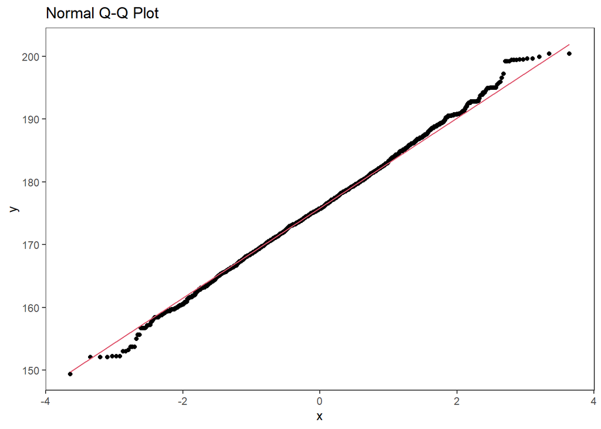

```r
## The histogram has the symmetric bell shape characteristic of the normal distribution,
## therefore the histogram suggests that the Height variable comes from a normal distribution.

# Create a Normal Q-Q plot for Height
subsetNHANES %>%                     ## Using the subsetNHANES filtered dataset,
  ggplot(aes(sample=Height)) +       ## set up the ggplot object with Height as the sample
  stat_qq() +                        ## draw the Q-Q plot
  stat_qq_line(color=2) +            ## draw the normal line in red
  labs(title="Normal Q-Q Plot") +    ## add title
  theme_bw() +                       ## remove gray background
  theme(panel.grid=element_blank())  ## remove grid
```

```r
## The Normal Q-Q plot follows the straight line very closely, despite a small deviation
## at both ends of the distribution. The Q-Q plot also suggests a normal distribution.

# Perform the Shapiro-Wilk test on the Height variable
subsetNHANES %>%        ## Using the subsetNHANES filtered dataset,
  pull(Height) %>%      ## take the Height variable and use it as a vector
  shapiro.test()        ## perform the Shapiro-Wilk test on that Height vector
```

```
##
##  Shapiro-Wilk normality test
##
## data:  .
## W = 0.99894, p-value = 0.02235
```

```r
# Base R alternative
shapiro.test(subsetNHANES$Height)
```

```
##
##  Shapiro-Wilk normality test
##
## data:  subsetNHANES$Height
## W = 0.99894, p-value = 0.02235
```

```r
## The Shapiro-Wilk test of normality has a p-value of 0.02, this is below the
## significance level of 0.05, therefore we can reject the null hypothesis that
## Height comes from a normal distribution, in other words the Height variable
## does not come from a normal distribution. However, 0.02 is quite close to 0.05,
## and a small deviation will cause a significant result in large samples.
## Here, we have n=3658 observations

# Test for normality of Height using the Kolmogorov-Smirnov test
subsetNHANES %>%                  ## Using the subsetNHANES filtered dataset,
  pull(Height) %>%                ## take the Height variable and use it as a vector
  ks.test(.,                      ## perform the Kolmogorov-Smirnov test on that Height vector
          "pnorm",                ## set the theoretical distribution as the normal probability distribution
          mean=mean(.),sd=sd(.))  ## estimate the mean and standard deviation from the Height sample
```

```
##
##  Asymptotic one-sample Kolmogorov-Smirnov test
##
## data:  .
## D = 0.016599, p-value = 0.2658
## alternative hypothesis: two-sided
```

```r
# Here you will get warnings about ties as the Kolmogorov-Smirnov test doesn't
# expect any ties in a continuous distribution.
## The Kolmogorov-Smirnov test has a p-value of 0.27, this is above the significance
## level of 0.05, therefore we cannot reject the null hypothesis that Height comes
## from a normal distribution, in other words, the Height variable comes from a normal distribution.

## Overall, it seems to be reasonable to assume that Height is normally distributed.
```

### WK2 - LAB

Check normal distribution both by * histogram * QQ-plot * shapiro-wilk * kolmogrov-smirnov ks.test(,.”pnorm”, mean=mean(.),sd=sd(.)) >> this is after the load of df and then pull(variable) as below

```r
### Week 2 lab - Checking the normality assumption

# In this self-guided lab, you will practice checking the assumption of normality in R using
# graphs and hypothesis tests.

# We'll be using functions from the tidyverse library, so let's load it in too.
library(tidyverse)

## Exercise 1  ----
# Using the NHANES dataset, imagine you want to investigate the difference in average diastolic
# blood pressure (BPDiaAve) between adult males and females. The exercise here is to check
# whether the normality assumption holds for each subgroup, using both graphs and hypothesis
# tests.


# We will be looking at the NHANES dataset, a survey dataset collected by the US National
# Center for Health Statistics (NCHS) which has conducted a series of health and nutrition
# surveys since the early 1960's. Since 1999, approximately 5,000 individuals of all ages are
# interviewed in their homes every year and complete the health examination component of the
# survey. Find out more here: https://cran.rstudio.com/web/packages/NHANES/index.html,
# and check the reference manual for the R package:
# https://cran.rstudio.com/web/packages/NHANES/NHANES.pdf

# Let's start by installing the NHANES package and loading it into R
install.packages("NHANES")
library(NHANES)

# Now let's tell R that we'll be using the NHANES data
data("NHANES")

# And let's have a quick look at the dataset
str(NHANES)
```

```
## tibble [10,000 × 76] (S3: tbl_df/tbl/data.frame)
##  $ ID              : int [1:10000] 51624 51624 51624 51625 51630 51638 51646 51647 51647 51647 ...
##  $ SurveyYr        : Factor w/ 2 levels "2009_10","2011_12": 1 1 1 1 1 1 1 1 1 1 ...
##  $ Gender          : Factor w/ 2 levels "female","male": 2 2 2 2 1 2 2 1 1 1 ...
##  $ Age             : int [1:10000] 34 34 34 4 49 9 8 45 45 45 ...
##  $ AgeDecade       : Factor w/ 8 levels " 0-9"," 10-19",..: 4 4 4 1 5 1 1 5 5 5 ...
##  $ AgeMonths       : int [1:10000] 409 409 409 49 596 115 101 541 541 541 ...
##  $ Race1           : Factor w/ 5 levels "Black","Hispanic",..: 4 4 4 5 4 4 4 4 4 4 ...
##  $ Race3           : Factor w/ 6 levels "Asian","Black",..: NA NA NA NA NA NA NA NA NA NA ...
##  $ Education       : Factor w/ 5 levels "8th Grade","9 - 11th Grade",..: 3 3 3 NA 4 NA NA 5 5 5 ...
##  $ MaritalStatus   : Factor w/ 6 levels "Divorced","LivePartner",..: 3 3 3 NA 2 NA NA 3 3 3 ...
##  $ HHIncome        : Factor w/ 12 levels " 0-4999"," 5000-9999",..: 6 6 6 5 7 11 9 11 11 11 ...
##  $ HHIncomeMid     : int [1:10000] 30000 30000 30000 22500 40000 87500 60000 87500 87500 87500 ...
##  $ Poverty         : num [1:10000] 1.36 1.36 1.36 1.07 1.91 1.84 2.33 5 5 5 ...
##  $ HomeRooms       : int [1:10000] 6 6 6 9 5 6 7 6 6 6 ...
```

[output cut: 62 more lines]

```r
head(NHANES)
```

```
## # A tibble: 6 × 76
##      ID SurveyYr Gender   Age AgeDecade AgeMonths Race1 Race3 Education
##   <int> <fct>    <fct>  <int> <fct>         <int> <fct> <fct> <fct>
## 1 51624 2009_10  male      34 " 30-39"        409 White <NA>  High School
## 2 51624 2009_10  male      34 " 30-39"        409 White <NA>  High School
## 3 51624 2009_10  male      34 " 30-39"        409 White <NA>  High School
## 4 51625 2009_10  male       4 " 0-9"           49 Other <NA>  <NA>
## 5 51630 2009_10  female    49 " 40-49"        596 White <NA>  Some College
## 6 51638 2009_10  male       9 " 0-9"          115 White <NA>  <NA>
## # ℹ 67 more variables: MaritalStatus <fct>, HHIncome <fct>, HHIncomeMid <int>,
## #   Poverty <dbl>, HomeRooms <int>, HomeOwn <fct>, Work <fct>, Weight <dbl>,
## #   Length <dbl>, HeadCirc <dbl>, Height <dbl>, BMI <dbl>,
## #   BMICatUnder20yrs <fct>, BMI_WHO <fct>, Pulse <int>, BPSysAve <int>,
## #   BPDiaAve <int>, BPSys1 <int>, BPDia1 <int>, BPSys2 <int>, BPDia2 <int>,
## #   BPSys3 <int>, BPDia3 <int>, Testosterone <dbl>, DirectChol <dbl>,
## #   TotChol <dbl>, UrineVol1 <int>, UrineFlow1 <dbl>, UrineVol2 <int>, …
```

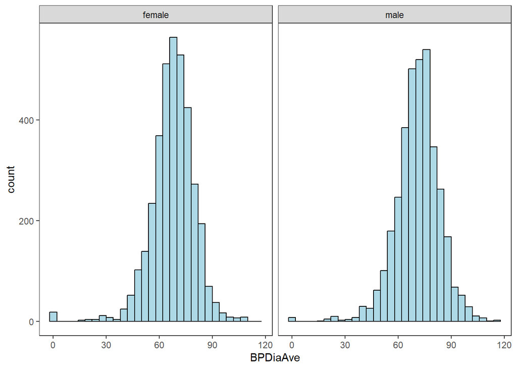

```r
# You'll notice that there are 76 variables and 10,000 observations in this dataset.
# The variables are a mix of numerical and categorical variables. For this exercise,
# we will focus on the numerical average diastolic blood pressure variable (BPDiaAve) and
# the categorical Gender variable.
# Remember to filter the dataset based on the numerical Age variable to keep only adult
# individuals (aged 18 or over), and based on the Gender to look at each subgroup separately.

## Your solution below:
subsetNHANES <- NHANES %>%
  filter(Age >= 18) %>%
  drop_na(BPDiaAve, Gender)

# Then we can check the assumption of normal distribution of the BPDiaAve
# variable. We can plot a histogram for BPDiaAve for each Gender.

subsetNHANES %>%
  ggplot(aes(x= BPDiaAve)) +
  geom_histogram(col="black", fill="lightblue", bins = 30) +
  facet_wrap(~Gender) +
  theme_bw() +
  theme(panel.grid = element_blank())
```

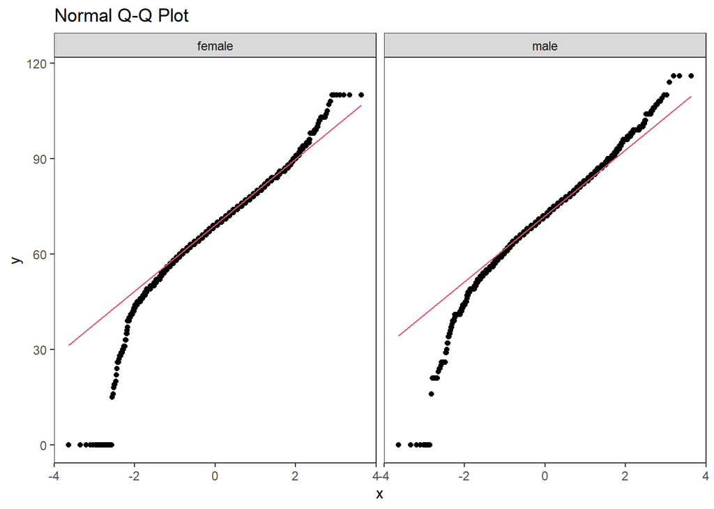

```r
# The histograms look close to normal, but there is a slightly longer left tail,
# suggesting that the data has a negative (or left-) skew. We can also plot a
# Normal Q-Q plot for BPDiaAve for each Gender.

subsetNHANES %>%
  ggplot(aes(sample=BPDiaAve)) +
  stat_qq() +
  stat_qq_line(color=2) +
  facet_wrap(~Gender) + ## plot Q-Q plots for each gender side-by-side
  labs(title="Normal Q-Q Plot") + ## add title
  theme_bw() + ## remove gray background
  theme(panel.grid=element_blank()) ## remove grid
```